# Risk Factor Analysis

## Outcome Variable

**Outcome Variable:** y_rate_haz

## Predictor Variables

**Intervention Variable:** fhtcm

**Adjustment Set:**

unadjusted

## Stratifying Variables

The analysis was stratified on these variable(s):

- agecat
- studyid
- country

## Data Summary

| agecat | studyid | country | fhtcm | n_cell | n |
| --- | --- | --- | --- | --- | --- |
| 0-3 months | ki1119695-PROBIT | BELARUS | [160-170) | 1277 | 11500 |
| 0-3 months | ki1119695-PROBIT | BELARUS | <160 | 52 | 11500 |
| 0-3 months | ki1119695-PROBIT | BELARUS | >=170 | 10171 | 11500 |
| 0-3 months | ki1101329-Keneba | GAMBIA | [160-170) | 529 | 965 |
| 0-3 months | ki1101329-Keneba | GAMBIA | <160 | 23 | 965 |
| 0-3 months | ki1101329-Keneba | GAMBIA | >=170 | 413 | 965 |
| 0-3 months | ki1135781-COHORTS | GUATEMALA | [160-170) | 88 | 180 |
| 0-3 months | ki1135781-COHORTS | GUATEMALA | <160 | 80 | 180 |
| 0-3 months | ki1135781-COHORTS | GUATEMALA | >=170 | 12 | 180 |
| 0-3 months | ki1000304b-SAS-CompFeed | INDIA | [160-170) | 412 | 716 |
| 0-3 months | ki1000304b-SAS-CompFeed | INDIA | <160 | 109 | 716 |
| 0-3 months | ki1000304b-SAS-CompFeed | INDIA | >=170 | 195 | 716 |
| 3-6 months | ki1119695-PROBIT | BELARUS | [160-170) | 1117 | 10104 |
| 3-6 months | ki1119695-PROBIT | BELARUS | <160 | 45 | 10104 |
| 3-6 months | ki1119695-PROBIT | BELARUS | >=170 | 8942 | 10104 |
| 3-6 months | ki1101329-Keneba | GAMBIA | [160-170) | 569 | 1037 |
| 3-6 months | ki1101329-Keneba | GAMBIA | <160 | 24 | 1037 |
| 3-6 months | ki1101329-Keneba | GAMBIA | >=170 | 444 | 1037 |
| 3-6 months | ki1135781-COHORTS | GUATEMALA | [160-170) | 131 | 261 |
| 3-6 months | ki1135781-COHORTS | GUATEMALA | <160 | 111 | 261 |
| 3-6 months | ki1135781-COHORTS | GUATEMALA | >=170 | 19 | 261 |
| 3-6 months | ki1000304b-SAS-CompFeed | INDIA | [160-170) | 389 | 682 |
| 3-6 months | ki1000304b-SAS-CompFeed | INDIA | <160 | 102 | 682 |
| 3-6 months | ki1000304b-SAS-CompFeed | INDIA | >=170 | 191 | 682 |
| 6-12 months | ki1119695-PROBIT | BELARUS | [160-170) | 1089 | 9870 |
| 6-12 months | ki1119695-PROBIT | BELARUS | <160 | 42 | 9870 |
| 6-12 months | ki1119695-PROBIT | BELARUS | >=170 | 8739 | 9870 |
| 6-12 months | ki1101329-Keneba | GAMBIA | [160-170) | 555 | 1005 |
| 6-12 months | ki1101329-Keneba | GAMBIA | <160 | 25 | 1005 |
| 6-12 months | ki1101329-Keneba | GAMBIA | >=170 | 425 | 1005 |
| 6-12 months | ki1135781-COHORTS | GUATEMALA | [160-170) | 164 | 329 |
| 6-12 months | ki1135781-COHORTS | GUATEMALA | <160 | 142 | 329 |
| 6-12 months | ki1135781-COHORTS | GUATEMALA | >=170 | 23 | 329 |
| 6-12 months | ki1000304b-SAS-CompFeed | INDIA | [160-170) | 387 | 679 |
| 6-12 months | ki1000304b-SAS-CompFeed | INDIA | <160 | 94 | 679 |
| 6-12 months | ki1000304b-SAS-CompFeed | INDIA | >=170 | 198 | 679 |
| 6-12 months | ki1000304b-SAS-FoodSuppl | INDIA | [160-170) | 199 | 328 |
| 6-12 months | ki1000304b-SAS-FoodSuppl | INDIA | <160 | 85 | 328 |
| 6-12 months | ki1000304b-SAS-FoodSuppl | INDIA | >=170 | 44 | 328 |
| 12-24 months | ki1119695-PROBIT | BELARUS | [160-170) | 253 | 2320 |
| 12-24 months | ki1119695-PROBIT | BELARUS | <160 | 15 | 2320 |
| 12-24 months | ki1119695-PROBIT | BELARUS | >=170 | 2052 | 2320 |
| 12-24 months | ki1101329-Keneba | GAMBIA | [160-170) | 527 | 931 |
| 12-24 months | ki1101329-Keneba | GAMBIA | <160 | 21 | 931 |
| 12-24 months | ki1101329-Keneba | GAMBIA | >=170 | 383 | 931 |
| 12-24 months | ki1135781-COHORTS | GUATEMALA | [160-170) | 206 | 421 |
| 12-24 months | ki1135781-COHORTS | GUATEMALA | <160 | 183 | 421 |
| 12-24 months | ki1135781-COHORTS | GUATEMALA | >=170 | 32 | 421 |

The following strata were considered:

- agecat: 0-3 months, studyid: ki1000304b-SAS-CompFeed, country: INDIA
- agecat: 0-3 months, studyid: ki1101329-Keneba, country: GAMBIA
- agecat: 0-3 months, studyid: ki1119695-PROBIT, country: BELARUS
- agecat: 0-3 months, studyid: ki1135781-COHORTS, country: GUATEMALA
- agecat: 12-24 months, studyid: ki1101329-Keneba, country: GAMBIA
- agecat: 12-24 months, studyid: ki1119695-PROBIT, country: BELARUS
- agecat: 12-24 months, studyid: ki1135781-COHORTS, country: GUATEMALA
- agecat: 3-6 months, studyid: ki1000304b-SAS-CompFeed, country: INDIA
- agecat: 3-6 months, studyid: ki1101329-Keneba, country: GAMBIA
- agecat: 3-6 months, studyid: ki1119695-PROBIT, country: BELARUS
- agecat: 3-6 months, studyid: ki1135781-COHORTS, country: GUATEMALA
- agecat: 6-12 months, studyid: ki1000304b-SAS-CompFeed, country: INDIA
- agecat: 6-12 months, studyid: ki1000304b-SAS-FoodSuppl, country: INDIA
- agecat: 6-12 months, studyid: ki1101329-Keneba, country: GAMBIA
- agecat: 6-12 months, studyid: ki1119695-PROBIT, country: BELARUS
- agecat: 6-12 months, studyid: ki1135781-COHORTS, country: GUATEMALA

## Methods Detail

We’re interested in the causal parameters $E[Y_a]$ for all values of $a \in \mathcal{A}$. These parameters represent the mean outcome if, possibly contrary to fact, we intervened to set all units to have $A=a$. Under the randomization and positivity assumptions, these are identified by the statistical parameters $\psi_a=E_W[E_{Y|A,W}(Y|A=a,W)]$. In addition, we’re interested in the mean of $Y$, $E[Y]$ under no intervention (the observed mean). We will estimate these parameters by using SuperLearner to fit the relevant likelihood factors – $E_{Y|A,W}(Y|A=a,W)$ and $p(A=a|W)$, and then updating our likelihood fit using a joint TMLE.

For unadjusted analyses ($W=\{\}$), initial likelihoods were estimated using Lrnr_glm to estimate the simple $E(Y|A)$ and Lrnr_mean to estimate $p(A)$. For adjusted analyses, a small library containing Lrnr_glmnet, Lrnr_xgboost, and Lrnr_mean was used.

Having estimated these parameters, we will then use the delta method to estimate relative risks and attributable risks relative to a prespecified baseline level of $A$.

# Results Detail

## Results Plots

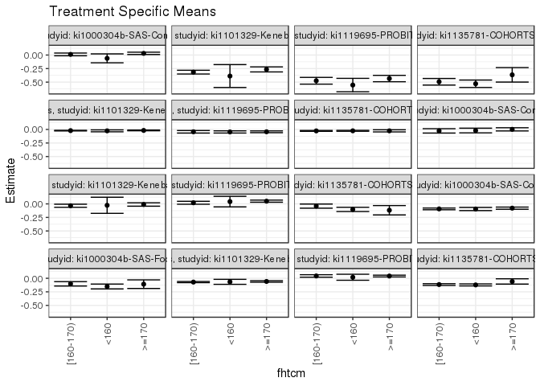

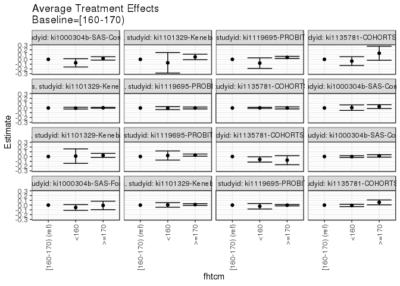

## Results Table

### Parameter: TSM

| agecat | studyid | country | intervention_level | baseline_level | estimate | ci_lower | ci_upper |
| --- | --- | --- | --- | --- | --- | --- | --- |
| 0-3 months | ki1000304b-SAS-CompFeed | INDIA | [160-170) | NA | 0.0117351 | -0.0131329 | 0.0366031 |
| 0-3 months | ki1000304b-SAS-CompFeed | INDIA | <160 | NA | -0.0610327 | -0.1435675 | 0.0215021 |
| 0-3 months | ki1000304b-SAS-CompFeed | INDIA | >=170 | NA | 0.0310840 | 0.0097076 | 0.0524605 |
| 0-3 months | ki1101329-Keneba | GAMBIA | [160-170) | NA | -0.3156532 | -0.3501413 | -0.2811650 |
| 0-3 months | ki1101329-Keneba | GAMBIA | <160 | NA | -0.3878102 | -0.5990354 | -0.1765851 |
| 0-3 months | ki1101329-Keneba | GAMBIA | >=170 | NA | -0.2651800 | -0.3118273 | -0.2185326 |
| 0-3 months | ki1119695-PROBIT | BELARUS | [160-170) | NA | -0.4748465 | -0.5372677 | -0.4124252 |
| 0-3 months | ki1119695-PROBIT | BELARUS | <160 | NA | -0.5539648 | -0.6776166 | -0.4303131 |
| 0-3 months | ki1119695-PROBIT | BELARUS | >=170 | NA | -0.4337496 | -0.4923505 | -0.3751487 |
| 0-3 months | ki1135781-COHORTS | GUATEMALA | [160-170) | NA | -0.4935801 | -0.5545369 | -0.4326232 |
| 0-3 months | ki1135781-COHORTS | GUATEMALA | <160 | NA | -0.5299265 | -0.5983824 | -0.4614706 |
| 0-3 months | ki1135781-COHORTS | GUATEMALA | >=170 | NA | -0.3652820 | -0.4991542 | -0.2314098 |
| 3-6 months | ki1000304b-SAS-CompFeed | INDIA | [160-170) | NA | -0.0260570 | -0.0664028 | 0.0142887 |
| 3-6 months | ki1000304b-SAS-CompFeed | INDIA | <160 | NA | -0.0196755 | -0.0629901 | 0.0236391 |
| 3-6 months | ki1000304b-SAS-CompFeed | INDIA | >=170 | NA | 0.0021438 | -0.0274970 | 0.0317845 |
| 3-6 months | ki1101329-Keneba | GAMBIA | [160-170) | NA | -0.0345709 | -0.0631943 | -0.0059475 |
| 3-6 months | ki1101329-Keneba | GAMBIA | <160 | NA | -0.0261402 | -0.1749792 | 0.1226988 |
| 3-6 months | ki1101329-Keneba | GAMBIA | >=170 | NA | -0.0111050 | -0.0425744 | 0.0203644 |
| 3-6 months | ki1119695-PROBIT | BELARUS | [160-170) | NA | 0.0204584 | -0.0066603 | 0.0475772 |
| 3-6 months | ki1119695-PROBIT | BELARUS | <160 | NA | 0.0419041 | -0.0556446 | 0.1394528 |
| 3-6 months | ki1119695-PROBIT | BELARUS | >=170 | NA | 0.0501718 | 0.0306347 | 0.0697089 |
| 3-6 months | ki1135781-COHORTS | GUATEMALA | [160-170) | NA | -0.0411125 | -0.0791351 | -0.0030899 |
| 3-6 months | ki1135781-COHORTS | GUATEMALA | <160 | NA | -0.1020145 | -0.1414055 | -0.0626235 |
| 3-6 months | ki1135781-COHORTS | GUATEMALA | >=170 | NA | -0.1176298 | -0.2040338 | -0.0312258 |
| 6-12 months | ki1000304b-SAS-CompFeed | INDIA | [160-170) | NA | -0.0927464 | -0.1084816 | -0.0770113 |
| 6-12 months | ki1000304b-SAS-CompFeed | INDIA | <160 | NA | -0.0945277 | -0.1237374 | -0.0653180 |
| 6-12 months | ki1000304b-SAS-CompFeed | INDIA | >=170 | NA | -0.0790450 | -0.0989921 | -0.0590979 |
| 6-12 months | ki1000304b-SAS-FoodSuppl | INDIA | [160-170) | NA | -0.1021807 | -0.1425067 | -0.0618547 |
| 6-12 months | ki1000304b-SAS-FoodSuppl | INDIA | <160 | NA | -0.1511644 | -0.1958726 | -0.1064562 |
| 6-12 months | ki1000304b-SAS-FoodSuppl | INDIA | >=170 | NA | -0.1085382 | -0.1881087 | -0.0289678 |
| 6-12 months | ki1101329-Keneba | GAMBIA | [160-170) | NA | -0.0698351 | -0.0809194 | -0.0587508 |
| 6-12 months | ki1101329-Keneba | GAMBIA | <160 | NA | -0.0653832 | -0.1111649 | -0.0196015 |
| 6-12 months | ki1101329-Keneba | GAMBIA | >=170 | NA | -0.0581866 | -0.0725458 | -0.0438274 |
| 6-12 months | ki1119695-PROBIT | BELARUS | [160-170) | NA | 0.0430414 | 0.0204463 | 0.0656364 |
| 6-12 months | ki1119695-PROBIT | BELARUS | <160 | NA | 0.0190922 | -0.0364150 | 0.0745995 |
| 6-12 months | ki1119695-PROBIT | BELARUS | >=170 | NA | 0.0416349 | 0.0250819 | 0.0581880 |
| 6-12 months | ki1135781-COHORTS | GUATEMALA | [160-170) | NA | -0.1156727 | -0.1320167 | -0.0993288 |
| 6-12 months | ki1135781-COHORTS | GUATEMALA | <160 | NA | -0.1222600 | -0.1409707 | -0.1035492 |
| 6-12 months | ki1135781-COHORTS | GUATEMALA | >=170 | NA | -0.0583483 | -0.1070108 | -0.0096858 |
| 12-24 months | ki1101329-Keneba | GAMBIA | [160-170) | NA | -0.0214765 | -0.0272863 | -0.0156668 |
| 12-24 months | ki1101329-Keneba | GAMBIA | <160 | NA | -0.0254189 | -0.0429976 | -0.0078402 |
| 12-24 months | ki1101329-Keneba | GAMBIA | >=170 | NA | -0.0178689 | -0.0247454 | -0.0109924 |
| 12-24 months | ki1119695-PROBIT | BELARUS | [160-170) | NA | -0.0428545 | -0.0664896 | -0.0192194 |
| 12-24 months | ki1119695-PROBIT | BELARUS | <160 | NA | -0.0457083 | -0.0658758 | -0.0255408 |
| 12-24 months | ki1119695-PROBIT | BELARUS | >=170 | NA | -0.0428974 | -0.0596876 | -0.0261071 |
| 12-24 months | ki1135781-COHORTS | GUATEMALA | [160-170) | NA | -0.0265187 | -0.0344791 | -0.0185584 |
| 12-24 months | ki1135781-COHORTS | GUATEMALA | <160 | NA | -0.0247565 | -0.0327956 | -0.0167173 |
| 12-24 months | ki1135781-COHORTS | GUATEMALA | >=170 | NA | -0.0255244 | -0.0451285 | -0.0059204 |

### Parameter: E(Y)

| agecat | studyid | country | intervention_level | baseline_level | estimate | ci_lower | ci_upper |
| --- | --- | --- | --- | --- | --- | --- | --- |
| 0-3 months | ki1000304b-SAS-CompFeed | INDIA | NA | NA | 0.0059269 | -0.0151835 | 0.0270374 |
| 0-3 months | ki1101329-Keneba | GAMBIA | NA | NA | -0.2957715 | -0.3237824 | -0.2677606 |
| 0-3 months | ki1119695-PROBIT | BELARUS | NA | NA | -0.4388567 | -0.4976461 | -0.3800673 |
| 0-3 months | ki1135781-COHORTS | GUATEMALA | NA | NA | -0.5011808 | -0.5450937 | -0.4572680 |
| 3-6 months | ki1000304b-SAS-CompFeed | INDIA | NA | NA | -0.0172047 | -0.0462110 | 0.0118016 |
| 3-6 months | ki1101329-Keneba | GAMBIA | NA | NA | -0.0243287 | -0.0453184 | -0.0033389 |
| 3-6 months | ki1119695-PROBIT | BELARUS | NA | NA | 0.0468501 | 0.0275580 | 0.0661423 |
| 3-6 months | ki1135781-COHORTS | GUATEMALA | NA | NA | -0.0725836 | -0.0990295 | -0.0461377 |
| 6-12 months | ki1000304b-SAS-CompFeed | INDIA | NA | NA | -0.0889976 | -0.1017879 | -0.0762074 |
| 6-12 months | ki1000304b-SAS-FoodSuppl | INDIA | NA | NA | -0.1157275 | -0.1449160 | -0.0865389 |
| 6-12 months | ki1101329-Keneba | GAMBIA | NA | NA | -0.0647984 | -0.0735026 | -0.0560942 |
| 6-12 months | ki1119695-PROBIT | BELARUS | NA | NA | 0.0416942 | 0.0249522 | 0.0584361 |
| 6-12 months | ki1135781-COHORTS | GUATEMALA | NA | NA | -0.1145084 | -0.1265939 | -0.1024228 |
| 12-24 months | ki1101329-Keneba | GAMBIA | NA | NA | -0.0200813 | -0.0244392 | -0.0157235 |
| 12-24 months | ki1119695-PROBIT | BELARUS | NA | NA | -0.0429109 | -0.0593629 | -0.0264588 |
| 12-24 months | ki1135781-COHORTS | GUATEMALA | NA | NA | -0.0256771 | -0.0311186 | -0.0202357 |

### Parameter: ATE

| agecat | studyid | country | intervention_level | baseline_level | estimate | ci_lower | ci_upper |
| --- | --- | --- | --- | --- | --- | --- | --- |
| 0-3 months | ki1000304b-SAS-CompFeed | INDIA | [160-170) | [160-170) | 0.0000000 | 0.0000000 | 0.0000000 |
| 0-3 months | ki1000304b-SAS-CompFeed | INDIA | <160 | [160-170) | -0.0727679 | -0.1595958 | 0.0140601 |
| 0-3 months | ki1000304b-SAS-CompFeed | INDIA | >=170 | [160-170) | 0.0193489 | -0.0155683 | 0.0542660 |
| 0-3 months | ki1101329-Keneba | GAMBIA | [160-170) | [160-170) | 0.0000000 | 0.0000000 | 0.0000000 |
| 0-3 months | ki1101329-Keneba | GAMBIA | <160 | [160-170) | -0.0721571 | -0.2861792 | 0.1418651 |
| 0-3 months | ki1101329-Keneba | GAMBIA | >=170 | [160-170) | 0.0504732 | -0.0075390 | 0.1084853 |
| 0-3 months | ki1119695-PROBIT | BELARUS | [160-170) | [160-170) | 0.0000000 | 0.0000000 | 0.0000000 |
| 0-3 months | ki1119695-PROBIT | BELARUS | <160 | [160-170) | -0.0791184 | -0.1896467 | 0.0314099 |
| 0-3 months | ki1119695-PROBIT | BELARUS | >=170 | [160-170) | 0.0410969 | 0.0188558 | 0.0633379 |
| 0-3 months | ki1135781-COHORTS | GUATEMALA | [160-170) | [160-170) | 0.0000000 | 0.0000000 | 0.0000000 |
| 0-3 months | ki1135781-COHORTS | GUATEMALA | <160 | [160-170) | -0.0363464 | -0.1280086 | 0.0553157 |
| 0-3 months | ki1135781-COHORTS | GUATEMALA | >=170 | [160-170) | 0.1282981 | -0.0187989 | 0.2753950 |
| 3-6 months | ki1000304b-SAS-CompFeed | INDIA | [160-170) | [160-170) | 0.0000000 | 0.0000000 | 0.0000000 |
| 3-6 months | ki1000304b-SAS-CompFeed | INDIA | <160 | [160-170) | 0.0063815 | -0.0515260 | 0.0642890 |
| 3-6 months | ki1000304b-SAS-CompFeed | INDIA | >=170 | [160-170) | 0.0282008 | -0.0129434 | 0.0693450 |
| 3-6 months | ki1101329-Keneba | GAMBIA | [160-170) | [160-170) | 0.0000000 | 0.0000000 | 0.0000000 |
| 3-6 months | ki1101329-Keneba | GAMBIA | <160 | [160-170) | 0.0084306 | -0.1431356 | 0.1599969 |
| 3-6 months | ki1101329-Keneba | GAMBIA | >=170 | [160-170) | 0.0234658 | -0.0190738 | 0.0660055 |
| 3-6 months | ki1119695-PROBIT | BELARUS | [160-170) | [160-170) | 0.0000000 | 0.0000000 | 0.0000000 |
| 3-6 months | ki1119695-PROBIT | BELARUS | <160 | [160-170) | 0.0214457 | -0.0738518 | 0.1167432 |
| 3-6 months | ki1119695-PROBIT | BELARUS | >=170 | [160-170) | 0.0297133 | 0.0066929 | 0.0527338 |
| 3-6 months | ki1135781-COHORTS | GUATEMALA | [160-170) | [160-170) | 0.0000000 | 0.0000000 | 0.0000000 |
| 3-6 months | ki1135781-COHORTS | GUATEMALA | <160 | [160-170) | -0.0609020 | -0.1156502 | -0.0061537 |
| 3-6 months | ki1135781-COHORTS | GUATEMALA | >=170 | [160-170) | -0.0765173 | -0.1709174 | 0.0178828 |
| 6-12 months | ki1000304b-SAS-CompFeed | INDIA | [160-170) | [160-170) | 0.0000000 | 0.0000000 | 0.0000000 |
| 6-12 months | ki1000304b-SAS-CompFeed | INDIA | <160 | [160-170) | -0.0017813 | -0.0203991 | 0.0168366 |
| 6-12 months | ki1000304b-SAS-CompFeed | INDIA | >=170 | [160-170) | 0.0137014 | -0.0116809 | 0.0390838 |
| 6-12 months | ki1000304b-SAS-FoodSuppl | INDIA | [160-170) | [160-170) | 0.0000000 | 0.0000000 | 0.0000000 |
| 6-12 months | ki1000304b-SAS-FoodSuppl | INDIA | <160 | [160-170) | -0.0489837 | -0.1091918 | 0.0112243 |
| 6-12 months | ki1000304b-SAS-FoodSuppl | INDIA | >=170 | [160-170) | -0.0063575 | -0.0955631 | 0.0828481 |
| 6-12 months | ki1101329-Keneba | GAMBIA | [160-170) | [160-170) | 0.0000000 | 0.0000000 | 0.0000000 |
| 6-12 months | ki1101329-Keneba | GAMBIA | <160 | [160-170) | 0.0044519 | -0.0426525 | 0.0515563 |
| 6-12 months | ki1101329-Keneba | GAMBIA | >=170 | [160-170) | 0.0116485 | -0.0064912 | 0.0297882 |
| 6-12 months | ki1119695-PROBIT | BELARUS | [160-170) | [160-170) | 0.0000000 | 0.0000000 | 0.0000000 |
| 6-12 months | ki1119695-PROBIT | BELARUS | <160 | [160-170) | -0.0239492 | -0.0809961 | 0.0330978 |
| 6-12 months | ki1119695-PROBIT | BELARUS | >=170 | [160-170) | -0.0014064 | -0.0157559 | 0.0129430 |
| 6-12 months | ki1135781-COHORTS | GUATEMALA | [160-170) | [160-170) | 0.0000000 | 0.0000000 | 0.0000000 |
| 6-12 months | ki1135781-COHORTS | GUATEMALA | <160 | [160-170) | -0.0065872 | -0.0314311 | 0.0182566 |
| 6-12 months | ki1135781-COHORTS | GUATEMALA | >=170 | [160-170) | 0.0573244 | 0.0059906 | 0.1086582 |
| 12-24 months | ki1101329-Keneba | GAMBIA | [160-170) | [160-170) | 0.0000000 | 0.0000000 | 0.0000000 |
| 12-24 months | ki1101329-Keneba | GAMBIA | <160 | [160-170) | -0.0039423 | -0.0224562 | 0.0145715 |
| 12-24 months | ki1101329-Keneba | GAMBIA | >=170 | [160-170) | 0.0036076 | -0.0053946 | 0.0126098 |
| 12-24 months | ki1119695-PROBIT | BELARUS | [160-170) | [160-170) | 0.0000000 | 0.0000000 | 0.0000000 |
| 12-24 months | ki1119695-PROBIT | BELARUS | <160 | [160-170) | -0.0028538 | -0.0337947 | 0.0280871 |
| 12-24 months | ki1119695-PROBIT | BELARUS | >=170 | [160-170) | -0.0000429 | -0.0200002 | 0.0199144 |
| 12-24 months | ki1135781-COHORTS | GUATEMALA | [160-170) | [160-170) | 0.0000000 | 0.0000000 | 0.0000000 |
| 12-24 months | ki1135781-COHORTS | GUATEMALA | <160 | [160-170) | 0.0017623 | -0.0095512 | 0.0130758 |
| 12-24 months | ki1135781-COHORTS | GUATEMALA | >=170 | [160-170) | 0.0009943 | -0.0201643 | 0.0221529 |